# 6.3 Other Levels of Confidence

## Goals

1. Use the normal distribution applet to find critical values.
2. Find and interpret confidence intervals for a mean when (A) the population is normal and (B) \(\sigma\) is known.

The 95% confidence interval is common in research, but there’s nothing inherently special about it.

- You could calculate a 90%, a 99%, or even something like a 43.8% confidence interval.
- These numbers are called the **confidence level**.
  - They represent the proportion of times that the parameter will fall in the interval (if we took many samples).

## Confidence Intervals

The 100(1-\(\alpha\))% confidence interval for \(\mu\) is given by \[\bar{x}\pm z_{\alpha/2}\frac{\sigma}{\sqrt{n}}\] where \(z_{\alpha/2}\) is the z-score associated with the \([1-(\alpha/2)]\)th percentile of the standard normal distribution.

## Critical Values

The value \(z_{\alpha/2}\) is called the **critical value** (“c.v.” on the plot, below).

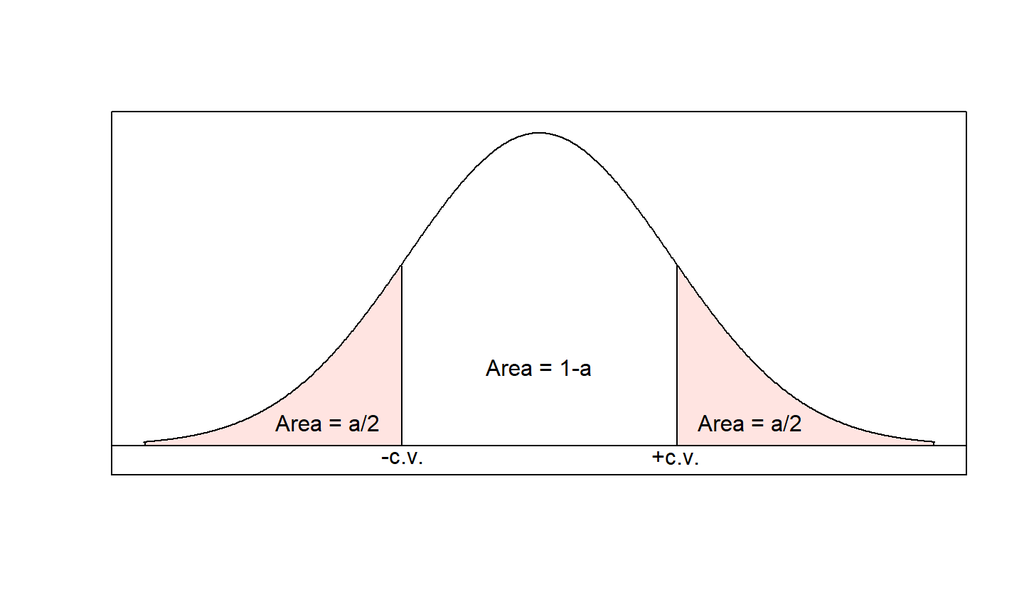

## Common Critical Values

| Confidence Level | \(\alpha\) | Critical Value, \(z_{\alpha/2}\) |
| --- | --- | --- |
| 90% | 0.10 | 1.645 |
| 95% | 0.05 | 1.96 |
| 98% | 0.02 | 2.326 |
| 99% | 0.01 | 2.575 |

## Example

Prior experience with SAT scores in the CSU system suggests that SAT scores are well-approximated by a normal distribution with standard deviation known to be 50. Suppose we have a random sample of 50 Sac State students with (sample) mean SAT score 1112.

1. Calculate a 98% confidence interval.
2. Interpret the interval in the context of the problem.

## Example

Use the [applet](https://www.rossmanchance.com/applets/2021/normcalc/NormCalc.html) to find critical values for the following levels of confidence:

1. 95%
2. 80%
3. 96%
4. 99.9%

## Breaking Down a Confidence Interval

\[\left(\bar{x}- z_{\alpha/2}\frac{\sigma}{\sqrt{n}}, \quad \bar{x} + z_{\alpha/2}\frac{\sigma}{\sqrt{n}}\right)\] The key values are

- \(\bar{x}\), the sample mean
- \(\sigma\), the population standard deviation
- \(n\), the sample size
- \(z_{\alpha/2}\), the critical value \[P(Z > z_{\alpha/2}) = \frac{\alpha}{2}\]

## Breaking Down a Confidence Interval

\[\left(\bar{x}- z_{\alpha/2}\frac{\sigma}{\sqrt{n}}, \quad \bar{x} + z_{\alpha/2}\frac{\sigma}{\sqrt{n}}\right)\]

- The value of interest is \(\mu\), the (unknown) population mean.
- The confidence interval gives us a reasonable range of values for \(\mu\).

In addition, the formula includes

- The standard error, \(\frac{\sigma}{\sqrt{n}}\)
- The margin of error, \(z_{\alpha/2}\frac{\sigma}{\sqrt{n}}\)

## Confidence Level

\[\left(\bar{x}- z_{\alpha/2}\frac{\sigma}{\sqrt{n}}, \quad \bar{x} + z_{\alpha/2}\frac{\sigma}{\sqrt{n}}\right)\]

If we can be 99% confident (or even higher), why do we tend to “settle” for 95%??

- What will higher levels of confidence do to this interval?